# Empreendedorismo de Base Tecnológica e Desenvolvimento Territorial

Empreendedorismo Tecnológico e Desenvolvimento Territorial · Aula 01

Prof. Dr. Luiz Diego Vidal Santos

## Unidade I Visão geral da aula

**01 · Arquitetura:** Contrato didático, ementa e avaliação (60 h).

**02 · Conceito de EBT:** Empreendedorismo de base tecnológica e critérios distintivos.

**03 · Schumpeter e Dosi:** *Mark I* e *II* vs. paradigmas, trajetórias e Estado Empreendedor.

**04 · Espaço e assimetrias:** Concentração espacial da inovação e Milton Santos.

**05 · Periferias e Brasil:** Janelas de especialização inteligente e desafios regionais.

**06 · Oficina inicial:** Mapeamento de demandas territoriais em duplas.

Propósito formativo Objetivo da aula

Apresentar a estrutura do componente curricular e fundamentar teoricamente o **empreendedorismo de base tecnológica** (EBT), articulando a tradição schumpeteriana da inovação às dinâmicas de concentração e desigualdade espacial no planejamento territorial.

Schumpeter & Dosi Mazzucato & Santos Território & CT&I

**Questão condutora:** Como converter conhecimento científico-tecnológico em valor enraizado no território, evitando que a inovação amplie desigualdades regionais?

# Arquitetura da Disciplina

## Unidade I Ementa, unidades e avaliação

| Unidade | Foco | Carga |
| --- | --- | --- |
| **I. Território e Ecossistemas** | EBT, barreiras, SRI, Hélice, Emp. Social | 24 h |
| **II. Processo e Estratégia** | Oportunidades, Canvas, Planos, *Spin-offs* | 20 h |
| **III. Projetos e Viabilidade** | Localização, VPL/TIR, *Valuation* | 12 h |
| **IV. Síntese Territorial** | Seminário Final Integrador | 4 h |

**Organização:** 60 horas distribuídas em 15 encontros, conectando teoria territorial, estratégia empreendedora e viabilidade econômico-locacional.

Composição da nota Sistema avaliativo

- **AV1 (30%):** Seminário e fichamento crítico (Unidade I).
- **AV2 (20%):** Estudo dirigido quantitativo e locacional (Unidade III).
- **AV3 (50%):** Trabalho final aplicado + defesa oral (20 min).

**Produto final esperado:** Diagnóstico de um ecossistema territorial ou proposta de empreendimento tecnológico/de impacto com viabilidade locacional e econômico-financeira.

# Empreendedorismo de Base Tecnológica

## Conceito O que define uma Empresa de Base Tecnológica?

Critérios (Bailetti, 2012; Storey & Tether, 1998) Conversão de conhecimento sob alta incerteza

- Não se reduz a “abrir qualquer empresa”: depende da **conversão de conhecimento científico-tecnológico** em soluções sob alta incerteza.
- **Ativos intangíveis centrais:** P&D, propriedade intelectual (patentes, *software*, cultivares), capital humano altamente qualificado e *know-how*.
- **Ciclo de maturação longo:** prova de conceito $\rightarrow$ protótipo $\rightarrow$ validação regulatória/de campo $\rightarrow$ escala comercial.

**Diferença-chave:** Enquanto o empreendedorismo por necessidade replica modelos existentes com baixa barreira técnica, o EBT cria novos mercados ou redefine fronteiras de produtividade.

| Tipo | Base de Conhecimento | Risco Principal |
| --- | --- | --- |
| *Deep Tech* | Ciência de fronteira (biotec, materiais, IA) | Risco tecnológico e regulatório |
| **Base Digital** | *Software*, plataformas, dados | Risco de adoção e escala |
| *Spin-off* Acadêmica | Pesquisa universitária / ICT | Transição bancada $\rightarrow$ mercado |
| **Tec. Social / Agro** | Tecnologia adaptada ao território | Apropriação local e governança |

## Síntese Inovação e assimetrias territoriais

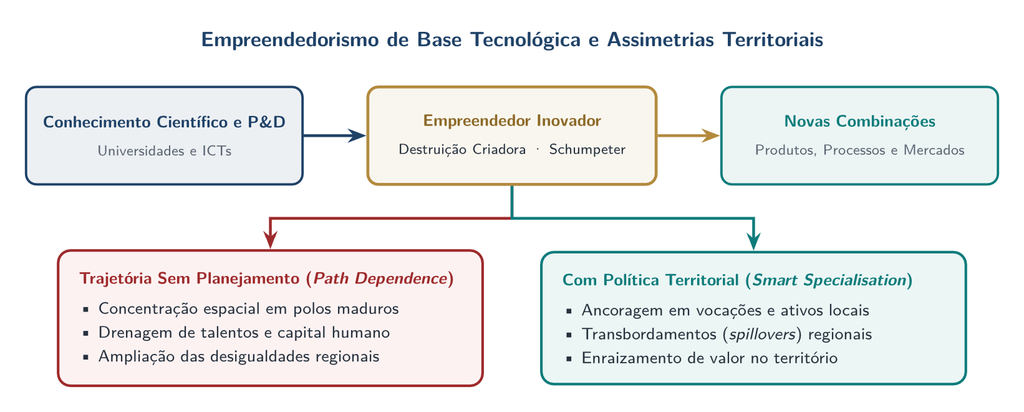

Conversão de P&D em novas combinações (Schumpeter) e bifurcação territorial entre concentração (path dependence) e especialização inteligente.

Empreendedorismo de base tecnológica e bifurcação territorial Conversão de P&D em novas combinações (Schumpeter) entre concentração (path dependence) e especialização inteligente

Sem política territorial deliberada de CT&I, o circuito da inovação tende a drenar talentos e ampliar assimetrias em favor dos polos já consolidados.

## Conceito Schumpeter e a destruição criadora

Schumpeter (1911; 1942) Os 5 tipos de inovação e os dois regimes

1. Introdução de um **novo bem** ou nova qualidade.
2. Novo **método de produção** ou processo.
3. Abertura de um **novo mercado**.
4. Nova fonte de **matérias-primas** ou insumos.
5. Nova **organização da indústria** (quebra ou formação de monopólio).
- **Mark I (1911):** empreendedor individual rompe o equilíbrio estacionário.
- **Mark II (1942):** P&D institucionalizado em grandes corporações.

Evolucionismo econômico Trajetórias tecnológicas (Dosi, 1982)

- A inovação não ocorre no vazio: segue **paradigmas** e **trajetórias tecnológicas** cumulativas.
- **Dependência de trajetória (*Path Dependence*):** territórios que acumulam infraestrutura de P&D e rotinas produtivas atraem mais EBT.

**Implicação territorial:** Sem política deliberada de CT&I e planejamento, a destruição criadora tende a **ampliar** a concentração de renda e talento nos polos já consolidados.

## Conceito De Thomas Kuhn (1962) a Giovanni Dosi (1982)

1 · Filosofia da ciência (Kuhn, 1962) Paradigmas, ciência normal e rupturas

- Em *A Estrutura das Revoluções Científicas*, **Thomas Kuhn** mostrou que a ciência evolui por **paradigmas** e rupturas, não de modo linear.
- **Ciência normal:** a comunidade resolve “quebra-cabeças” dentro de um modelo compartilhado (ex.: mecânica de Newton).
- Anomalias insolúveis disparam uma **revolução científica** e um novo paradigma (ex.: relatividade e mecânica quântica).
- **Transposição de Dosi (1982):** engenheiros, centros de P&D e firmas inovam na economia como os cientistas de Kuhn.

*“Um **modelo e padrão de solução** de problemas tecnológicos selecionados com base em **princípios da ciência natural**…”* (Dosi, 1982)

| Problema Prático | Princípio da Ciência Natural | Paradigma Resultante |
| --- | --- | --- |
| **Transporte** | Termodinâmica de hidrocarbonetos | Motor a combustão interna |
| **Cálculo e Dados** | Física dos semicondutores | Microeletrônica (silício/transistor) |
| **Iluminação** | Incandescência $\rightarrow$ Eletroluminescência | Filamento de tungstênio $\rightarrow$ LED |

## Síntese Transposição epistemológica: de Kuhn a Dosi

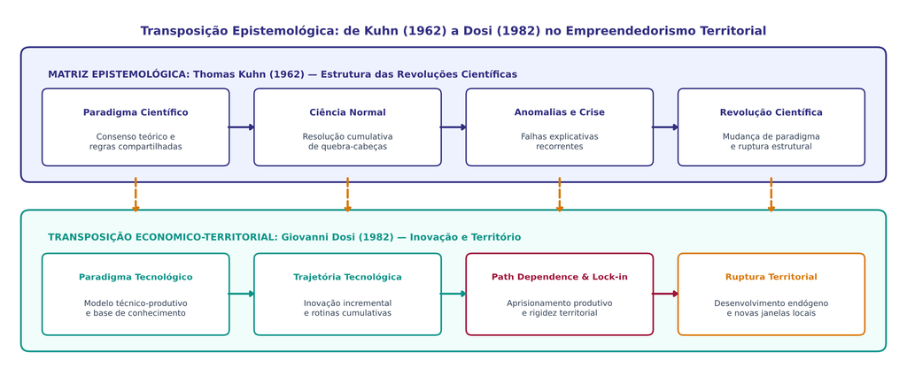

Transposição epistemológica da matriz de Thomas Kuhn (1962) para os paradigmas e trajetórias tecnológicas de Giovanni Dosi (1982).

De Kuhn (1962) a Dosi (1982) no empreendedorismo territorial Da matriz científica (paradigma, ciência normal, anomalias, revolução) à dinâmica econômica (trajetória, path dependence, lock-in e ruptura territorial)

A leitura kuhniana explica por que a transição para novas bases produtivas exige mudança de paradigma científico-tecnológico, e não apenas incentivo incremental.

## Território Trajetória tecnológica, path dependence e lock-in

Dinâmica tecnológica O desdobramento prático do paradigma

- **Trajetória tecnológica (“ciência normal” da engenharia):** empresas passam décadas aperfeiçoando o mesmo princípio (injeção eletrônica e catalisadores; Lei de Moore no chip de silício).
- *Path Dependence* e *Lock-in*: refinarias, autopeças, rodovias, currículos de engenharia e marcos regulatórios moldam-se ao paradigma dominante.
- O sistema produtivo fica **aprisionado (*locked-in*)**, tornando custosa a mudança mesmo diante de crise ecológica ou obsolescência.

Leitura PLANTERR Por que isso decide o planejamento territorial?

- Um planejador regional não pode supor que um decreto ou incentivo fiscal isolado reconverte automaticamente a economia local.
- **Inércia territorial na Bahia:** polos maduros (como o polo petroquímico ou bacias agroindustriais convencionais) sofrem de **inércia cognitiva e dependência de trajetória**.
- **Transição (Bioeconomia / Renováveis):** exige **mudança de paradigma tecnológico**, alterando a base científica, universidades/ICTs e redes locais de aprendizado.

## Crítica Limites do modelo schumpeteriano

1 · Determinismo e rotinização Dosi, Perez e Teece vs. Mark II

- Schumpeter (*Mark II*) previu a obsolescência do empreendedor individual pela burocratização do P&D em megacorporações.
- **Ruptura empírica:** revoluções em TICs, biotecnologia e IA mostraram que grandes corporações sofrem de **inércia cognitiva** e aprisionamento em trajetórias estabelecidas (*path dependence*).
- Novas firmas tecnológicas e redes abertas rompem paradigmas justamente onde o oligopólio é conservador.

2 · Mito do empreendedor isolado Mazzucato (2014) e o risco estatal

- Confronta a narrativa heroica de que o capital privado e o *venture capital* movem sozinhos a fronteira tecnológica.
- **Evidência histórica:** o capital privado só entra quando as incertezas radicais já foram absorvidas por décadas de **investimento público estatal de alto risco** e capital paciente (universidades, laboratórios públicos e encomendas estatais).

**Tensão para a AV1:** Quem assume o risco tecnológico fundacional no território e quem apropria os retornos privados?

# Espaço, Assimetrias e Território

## Território Por que o EBT se concentra no espaço?

Audretsch & Feldman (1996) Fatores de aglomeração

- *Knowledge spillovers*: conhecimento tácito exige interação face a face e proximidade geográfica.
- **Mercado de trabalho especializado:** concentração de engenheiros, pesquisadores e gestores.
- **Infraestrutura científica e financeira:** universidades, laboratórios, investidores-anjo e *venture capital*.
- **Urbanização vs. especialização:** diversidade metropolitana (Jacobs) *versus* densidade setorial (Marshall-Arrow-Romer).

Geografia desigual O Brasil no mapa da inovação

- Forte concentração regional de dispêndio em P&D, patentes e *startups* no eixo **Sul–Sudeste** (com polos pontuais no Nordeste, como Recife/Porto Digital e Salvador/Camaçari).
- **Desafio do planejamento territorial:** conectar ativos locais (biodiversidade, agroecossistemas, energias renováveis, universidades estaduais e federais) a cadeias de valor tecnológico.

**Referência-chave (Milton Santos):** A difusão desigual do *meio técnico-científico-informacional* cria “luminosidades” e “opacidades” no território nacional.

## Território Empreendedorismo fora dos grandes centros

Especialização Inteligente (Foray, 2015) Janelas de oportunidade territorial

- **Smart Specialisation:** priorizar nichos onde o território possui vantagem comparativa latente.
- **Exemplos no Nordeste / Bahia:**
  - *Agtechs* e bioeconomia do Semiárido (recursos hídricos, caatinga, fruticultura irrigada).
  - Energias renováveis (cadeia eólica e solar) e serviços tecnológicos associados.
  - Tecnologias ambientais e restauração produtiva.

Critérios de análise Perguntas orientadoras para o planejador

1. O empreendimento tecnológico **enraíza** valor no território ou apenas extrai dados e recursos?
2. Há massa crítica institucional (universidades, IFs, prefeituras, associações) para sustentar a aprendizagem coletiva?
3. Quais barreiras infraestruturais (logística, conectividade, crédito) bloqueiam a escala local?

# Oficina Prática e Síntese

## Método Oficina diagnóstica e leituras (Eixos 1 e 2)

**Oficina diagnóstica (45 min):** Em duplas, escolha um **território de referência** (município, bacia ou território de identidade da Bahia) e responda:

**01 · Gargalo territorial:** Qual é o principal gargalo produtivo ou socioambiental desse território?

**02 · Base científica local:** Que base de conhecimento existente (UEFS, UFRB, IFBA, Embrapa etc.) poderia endereçar esse gargalo?

**03 · Tipologia do negócio:** O eventual empreendimento seria *deep tech*, digital, *spin-off* ou tecnologia social?

Bibliografia fundamental Leituras da Aula 01 e próxima aula (Eixos 1 e 2)

- **KUHN, T. S.** *A estrutura das revoluções científicas*. Perspectiva, 1962; **DOSI, G.** *Technological paradigms and technological trajectories*. Research Policy, 1982.
- **BAILETTI, T.** *Technology entrepreneurship: overview, definition, and distinctive aspects*. TIM Review, 2012.
- **SANTOS, M.** *A Natureza do Espaço: Técnica e Tempo, Razão e Emoção*. Hucitec, 1996.
- **PORTER, M. E.** *Estratégia competitiva* (Cap. 1) e *Clusters and the new economics of competition* (HBR, 1998).
- **CASSIOLATO, J. E.; LASTRES, H. M. M.** *Sistemas de inovação e desenvolvimento: as implicações de política*. São Paulo em Perspectiva, 2005.